# Credit Card Fraud Prediction

## Author : Nagarjuna Tella

A lot of companies handle huge amounts of transactions, they are able differentiate between fraudlent and non fradulent transactions. These companies handle this challenge by implementing Fraud Detection System (FDS). The best way to get a sense of the challenges underlying the design of a credit card fraud detection system (FDS) is by designing one.

```python
import pandas as pd
import numpy as np
import matplotlib.pyplot as plt
import seaborn as sns
import sklearn.metrics as met
import sklearn.naive_bayes as nb
import sklearn.ensemble as en
import sys
import warnings
from sklearn import tree
from sklearn.model_selection import GridSearchCV
from sklearn.preprocessing import StandardScaler
from sklearn.linear_model import LogisticRegression
from sklearn.model_selection import train_test_split
from sklearn.utils import resample
from imblearn.over_sampling import RandomOverSampler
from sdv.tabular import GaussianCopula
from xgboost import XGBClassifier
from imblearn.over_sampling import SMOTE
from statsmodels.stats.outliers_influence import variance_inflation_factor
```

```python
# Handling Warning Messages
if not sys.warnoptions:
    warnings.simplefilter("ignore")
```

```python
# Load Data
data = pd.read_csv('./creditcard.csv')
```

# EDA

```python
data.head()
```

|  | Time | V1 | V2 | V3 | V4 | V5 | V6 | V7 | V8 | V9 | ... | V21 | V22 | V23 | V24 | V25 | V26 | V27 | V28 | Amount | Class |
| --- | --- | --- | --- | --- | --- | --- | --- | --- | --- | --- | --- | --- | --- | --- | --- | --- | --- | --- | --- | --- | --- |
| 0 | 0.0 | -1.359807 | -0.072781 | 2.536347 | 1.378155 | -0.338321 | 0.462388 | 0.239599 | 0.098698 | 0.363787 | ... | -0.018307 | 0.277838 | -0.110474 | 0.066928 | 0.128539 | -0.189115 | 0.133558 | -0.021053 | 149.62 | 0 |
| 1 | 0.0 | 1.191857 | 0.266151 | 0.166480 | 0.448154 | 0.060018 | -0.082361 | -0.078803 | 0.085102 | -0.255425 | ... | -0.225775 | -0.638672 | 0.101288 | -0.339846 | 0.167170 | 0.125895 | -0.008983 | 0.014724 | 2.69 | 0 |
| 2 | 1.0 | -1.358354 | -1.340163 | 1.773209 | 0.379780 | -0.503198 | 1.800499 | 0.791461 | 0.247676 | -1.514654 | ... | 0.247998 | 0.771679 | 0.909412 | -0.689281 | -0.327642 | -0.139097 | -0.055353 | -0.059752 | 378.66 | 0 |
| 3 | 1.0 | -0.966272 | -0.185226 | 1.792993 | -0.863291 | -0.010309 | 1.247203 | 0.237609 | 0.377436 | -1.387024 | ... | -0.108300 | 0.005274 | -0.190321 | -1.175575 | 0.647376 | -0.221929 | 0.062723 | 0.061458 | 123.50 | 0 |
| 4 | 2.0 | -1.158233 | 0.877737 | 1.548718 | 0.403034 | -0.407193 | 0.095921 | 0.592941 | -0.270533 | 0.817739 | ... | -0.009431 | 0.798278 | -0.137458 | 0.141267 | -0.206010 | 0.502292 | 0.219422 | 0.215153 | 69.99 | 0 |

5 rows × 31 columns

```python
data.info()
```

```
<class 'pandas.core.frame.DataFrame'>
RangeIndex: 284807 entries, 0 to 284806
Data columns (total 31 columns):
 #   Column  Non-Null Count   Dtype
---  ------  --------------   -----
 0   Time    284807 non-null  float64
 1   V1      284807 non-null  float64
 2   V2      284807 non-null  float64
 3   V3      284807 non-null  float64
 4   V4      284807 non-null  float64
 5   V5      284807 non-null  float64
 6   V6      284807 non-null  float64
 7   V7      284807 non-null  float64
 8   V8      284807 non-null  float64
 9   V9      284807 non-null  float64
```

[output cut: 23 more lines]

```python
data.describe().T
```

|  | count | mean | std | min | 25% | 50% | 75% | max |
| --- | --- | --- | --- | --- | --- | --- | --- | --- |
| Time | 284807.0 | 9.481386e+04 | 47488.145955 | 0.000000 | 54201.500000 | 84692.000000 | 139320.500000 | 172792.000000 |
| V1 | 284807.0 | 1.168375e-15 | 1.958696 | -56.407510 | -0.920373 | 0.018109 | 1.315642 | 2.454930 |
| V2 | 284807.0 | 3.416908e-16 | 1.651309 | -72.715728 | -0.598550 | 0.065486 | 0.803724 | 22.057729 |
| V3 | 284807.0 | -1.379537e-15 | 1.516255 | -48.325589 | -0.890365 | 0.179846 | 1.027196 | 9.382558 |
| V4 | 284807.0 | 2.074095e-15 | 1.415869 | -5.683171 | -0.848640 | -0.019847 | 0.743341 | 16.875344 |
| V5 | 284807.0 | 9.604066e-16 | 1.380247 | -113.743307 | -0.691597 | -0.054336 | 0.611926 | 34.801666 |
| V6 | 284807.0 | 1.487313e-15 | 1.332271 | -26.160506 | -0.768296 | -0.274187 | 0.398565 | 73.301626 |
| V7 | 284807.0 | -5.556467e-16 | 1.237094 | -43.557242 | -0.554076 | 0.040103 | 0.570436 | 120.589494 |
| V8 | 284807.0 | 1.213481e-16 | 1.194353 | -73.216718 | -0.208630 | 0.022358 | 0.327346 | 20.007208 |
| V9 | 284807.0 | -2.406331e-15 | 1.098632 | -13.434066 | -0.643098 | -0.051429 | 0.597139 | 15.594995 |
| V10 | 284807.0 | 2.239053e-15 | 1.088850 | -24.588262 | -0.535426 | -0.092917 | 0.453923 | 23.745136 |
| V11 | 284807.0 | 1.673327e-15 | 1.020713 | -4.797473 | -0.762494 | -0.032757 | 0.739593 | 12.018913 |
| V12 | 284807.0 | -1.247012e-15 | 0.999201 | -18.683715 | -0.405571 | 0.140033 | 0.618238 | 7.848392 |
| V13 | 284807.0 | 8.190001e-16 | 0.995274 | -5.791881 | -0.648539 | -0.013568 | 0.662505 | 7.126883 |
| V14 | 284807.0 | 1.207294e-15 | 0.958596 | -19.214325 | -0.425574 | 0.050601 | 0.493150 | 10.526766 |
| V15 | 284807.0 | 4.887456e-15 | 0.915316 | -4.498945 | -0.582884 | 0.048072 | 0.648821 | 8.877742 |
| V16 | 284807.0 | 1.437716e-15 | 0.876253 | -14.129855 | -0.468037 | 0.066413 | 0.523296 | 17.315112 |
| V17 | 284807.0 | -3.772171e-16 | 0.849337 | -25.162799 | -0.483748 | -0.065676 | 0.399675 | 9.253526 |
| V18 | 284807.0 | 9.564149e-16 | 0.838176 | -9.498746 | -0.498850 | -0.003636 | 0.500807 | 5.041069 |
| V19 | 284807.0 | 1.039917e-15 | 0.814041 | -7.213527 | -0.456299 | 0.003735 | 0.458949 | 5.591971 |
| V20 | 284807.0 | 6.406204e-16 | 0.770925 | -54.497720 | -0.211721 | -0.062481 | 0.133041 | 39.420904 |
| V21 | 284807.0 | 1.654067e-16 | 0.734524 | -34.830382 | -0.228395 | -0.029450 | 0.186377 | 27.202839 |
| V22 | 284807.0 | -3.568593e-16 | 0.725702 | -10.933144 | -0.542350 | 0.006782 | 0.528554 | 10.503090 |
| V23 | 284807.0 | 2.578648e-16 | 0.624460 | -44.807735 | -0.161846 | -0.011193 | 0.147642 | 22.528412 |
| V24 | 284807.0 | 4.473266e-15 | 0.605647 | -2.836627 | -0.354586 | 0.040976 | 0.439527 | 4.584549 |
| V25 | 284807.0 | 5.340915e-16 | 0.521278 | -10.295397 | -0.317145 | 0.016594 | 0.350716 | 7.519589 |
| V26 | 284807.0 | 1.683437e-15 | 0.482227 | -2.604551 | -0.326984 | -0.052139 | 0.240952 | 3.517346 |
| V27 | 284807.0 | -3.660091e-16 | 0.403632 | -22.565679 | -0.070840 | 0.001342 | 0.091045 | 31.612198 |
| V28 | 284807.0 | -1.227390e-16 | 0.330083 | -15.430084 | -0.052960 | 0.011244 | 0.078280 | 33.847808 |
| Amount | 284807.0 | 8.834962e+01 | 250.120109 | 0.000000 | 5.600000 | 22.000000 | 77.165000 | 25691.160000 |
| Class | 284807.0 | 1.727486e-03 | 0.041527 | 0.000000 | 0.000000 | 0.000000 | 0.000000 | 1.000000 |

Checking and dropping duplicates

```python
data.duplicated().sum()
```

```
1081
```

```python
data.drop_duplicates(inplace=True)
```

Class counts after dropping duplicates

```python
data.Class.value_counts()
```

```
0    283253
1       473
Name: Class, dtype: int64
```

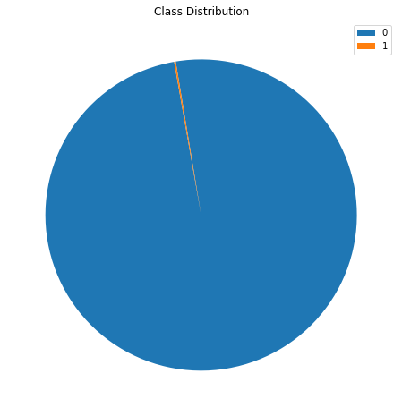

```python
plt.figure(figsize=(8, 8))
plt.pie(data['Class'].value_counts(), startangle=100)
plt.legend(labels=['0', '1'])
plt.title('Class Distribution')
plt.show()
```

```python
print('No Frauds', round(data['Class'].value_counts()[0] / len(data) * 100, 2), '% of the dataset')
print('Frauds', round(data['Class'].value_counts()[1] / len(data) * 100, 2), '% of the dataset')
```

```
No Frauds 99.83 % of the dataset
Frauds 0.17 % of the dataset
```

Dataset is highly imbalanced

```python
print(data[data.Class == 0].Amount.describe())
print(data[data.Class == 1].Amount.describe())
```

```
count    283253.000000
mean         88.413575
std         250.379023
min           0.000000
25%           5.670000
50%          22.000000
75%          77.460000
max       25691.160000
Name: Amount, dtype: float64
count     473.000000
mean      123.871860
std       260.211041
min         0.000000
25%         1.000000
50%         9.820000
75%       105.890000
max      2125.870000
Name: Amount, dtype: float64
```

```python
print(data[['Time', 'Amount', 'Class']].groupby('Class').describe())
```

```
           Time                                                       \
          count          mean           std    min      25%      50%
Class
0      283253.0  94835.058093  47475.550607    0.0  54233.0  84711.0
1         473.0  80450.513742  48636.179973  406.0  41203.0  73408.0

                             Amount                                            \
            75%       max     count        mean         std  min   25%    50%
Class
0      139308.0  172792.0  283253.0   88.413575  250.379023  0.0  5.67  22.00
1      129095.0  170348.0     473.0  123.871860  260.211041  0.0  1.00   9.82


          75%       max
Class
0       77.46  25691.16
1      105.89   2125.87
```

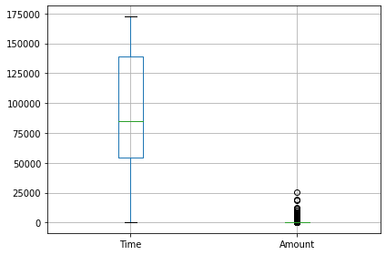

```python
data.boxplot(['Time', 'Amount'])
plt.tight_layout()
plt.show()
```

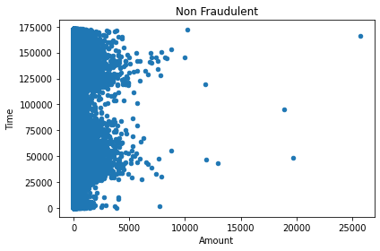

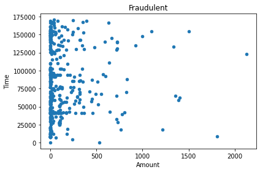

```python
data[data.Class == 0].plot.scatter('Amount', 'Time')
plt.title('Non Fraudulent')
plt.tight_layout()
plt.show()
data[data.Class == 1].plot.scatter('Amount', 'Time')
plt.title('Fraudulent')
plt.tight_layout()
plt.show()
```

Removing outliers from the data

```python
data = data.drop(data[data.Amount > 10000].index, axis=0)
```

### Coorelation of features

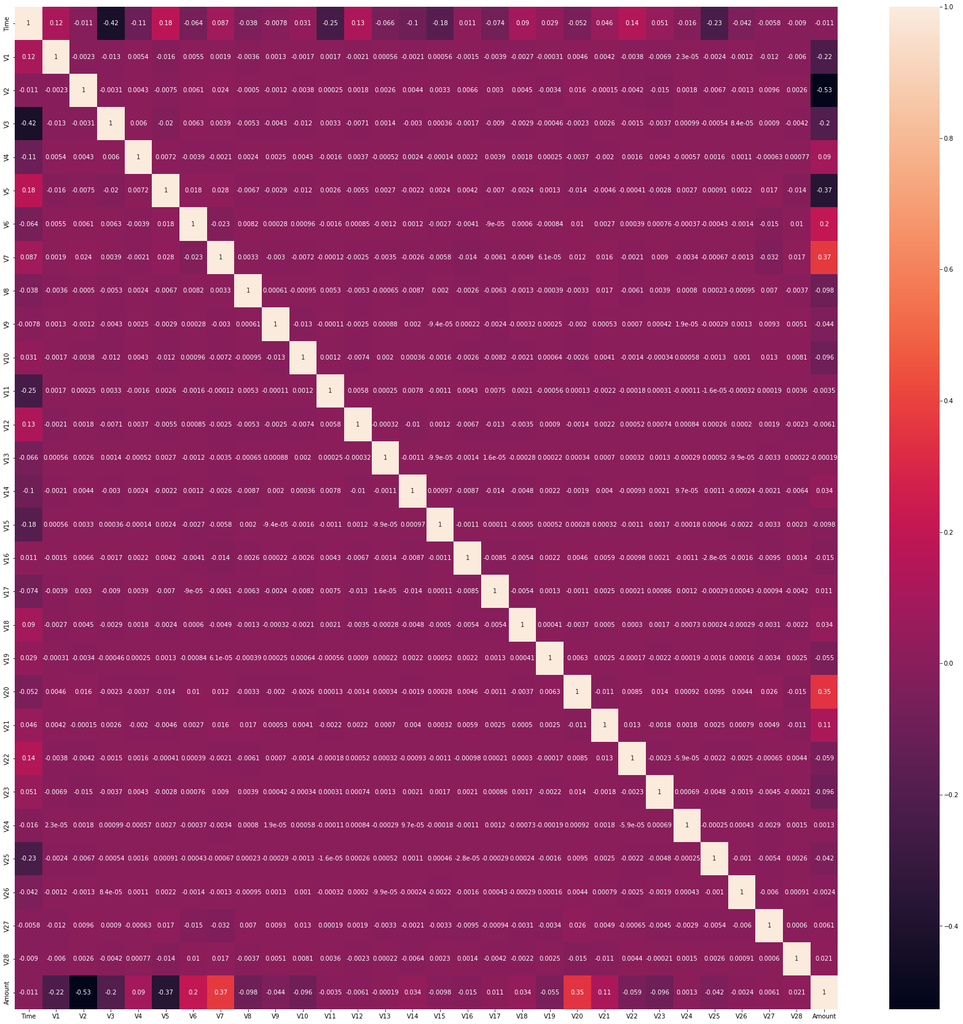

```python
x = data.drop('Class', axis=1)
y = data.Class.values

corr_mtx = x.corr()
plt.figure(figsize=(30, 30))
sns.heatmap(corr_mtx, annot=True)
plt.show()
```

### Feature Importance (Logistic Regression)

Need to remove unessesary features from the dataset to improve the computation and decrease dimensionality of the dataset.

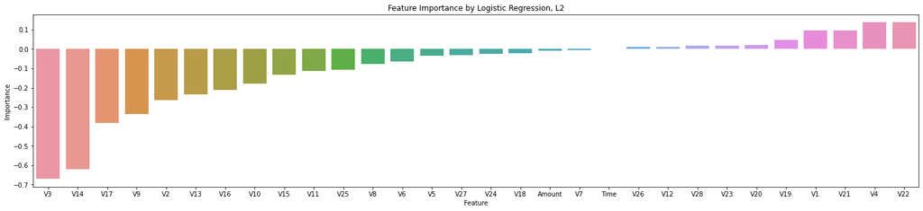

```python
fi_ml = LogisticRegression(max_iter=200, solver='liblinear')
fi_ml.fit(x, y)

coef = pd.concat([pd.DataFrame(x.columns), pd.DataFrame(np.transpose(fi_ml.coef_))], axis=1)
coef.columns = ['Feature', 'Importance']
coef.sort_values(by='Importance', inplace=True)

plt.figure(figsize=(25, 5))
sns.barplot(data=coef, x='Feature', y='Importance')
plt.title('Feature Importance by Logistic Regression, L2')
plt.show()
```

```python
data = data.drop(columns=['Time', 'Amount', 'V7'])
x = x.drop(columns=['Time', 'Amount', 'V7'], axis=1)
```

### Variance Inflation Factor

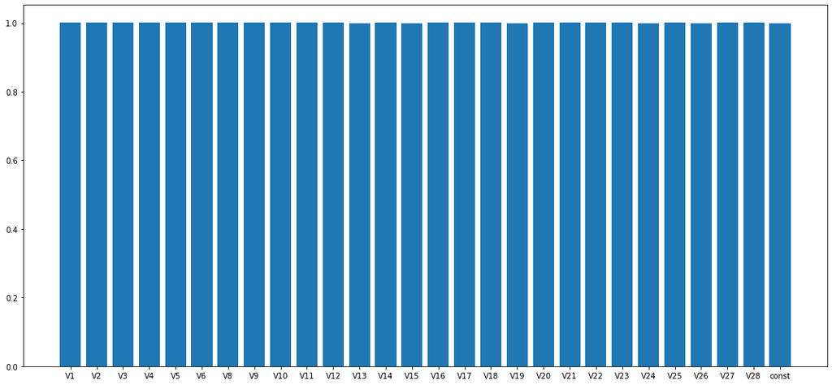

```python
tes = x.assign(const=1)
res = pd.Series([variance_inflation_factor(tes.values, i)
                 for i in range(tes.shape[1])],
                index=tes.columns)

plt.figure(figsize=(15, 7))
plt.bar(res.index, res.values)
plt.tight_layout()
plt.show()
```

```python
res.nlargest(5)
```

```
V5     1.002253
V20    1.002181
V27    1.002103
V3     1.001136
V6     1.001076
dtype: float64
```

```python
x = x.drop(columns=['V5', 'V20', 'V27', 'V3', 'V6'], axis=1)
```

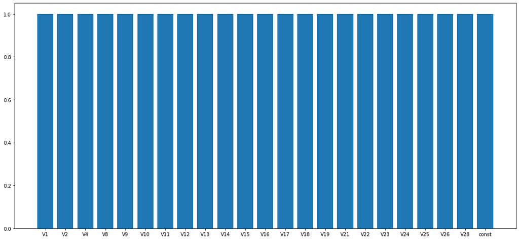

```python
tes = x.assign(const=1)
res = pd.Series([variance_inflation_factor(tes.values, i)
                 for i in range(tes.shape[1])],
                index=tes.columns)

plt.figure(figsize=(15, 7))
plt.bar(res.index, res.values)
plt.tight_layout()
plt.show()
```

```python
res.nlargest(5)
```

```
V21    1.000732
V17    1.000727
V14    1.000662
V8     1.000583
V12    1.000513
dtype: float64
```

```python
x = x.drop(columns=['V21', 'V17', 'V14', 'V8', 'V12'], axis=1)
```

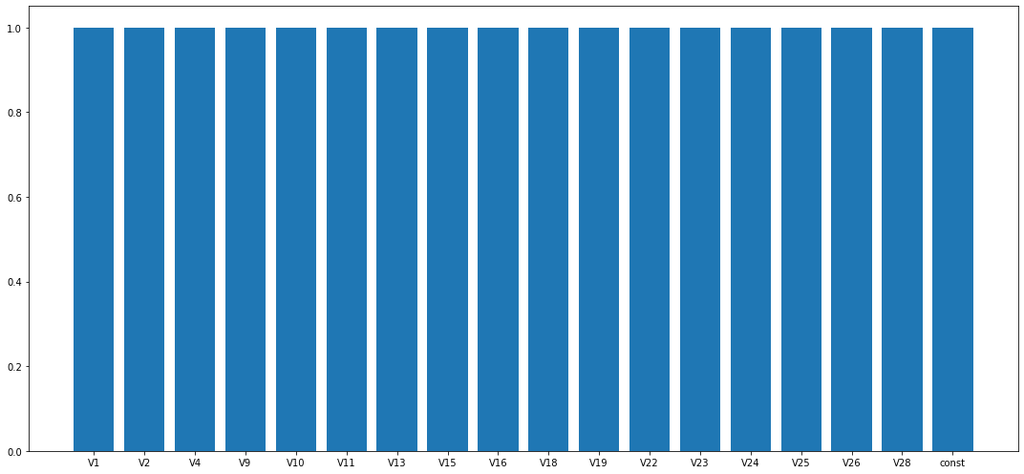

```python
tes = x.assign(const=1)
res = pd.Series([variance_inflation_factor(tes.values, i)
                 for i in range(tes.shape[1])],
                index=tes.columns)

plt.figure(figsize=(15, 7))
plt.bar(res.index, res.values)
plt.tight_layout()
plt.show()
```

```python
res.nlargest(5)
```

```
V2     1.000450
V23    1.000358
V10    1.000296
V9     1.000208
V28    1.000195
dtype: float64
```

```python
x = x.drop(columns=['V2', 'V23', 'V10', 'V9', 'V28'], axis=1)
```

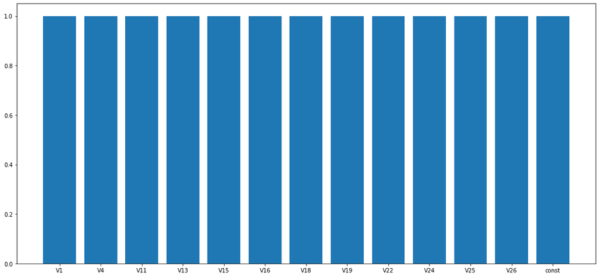

```python
tes = x.assign(const=1)
res = pd.Series([variance_inflation_factor(tes.values, i)
                 for i in range(tes.shape[1])],
                index=tes.columns)

plt.figure(figsize=(15, 7))
plt.bar(res.index, res.values)
plt.tight_layout()
plt.show()
```

```python
res.nlargest(5)
```

```
V16    1.000068
V1     1.000064
V4     1.000047
V18    1.000046
V22    1.000031
dtype: float64
```

```python
x = x.drop(columns=['V16', 'V1', 'V4', 'V18', 'V22'], axis=1)
```

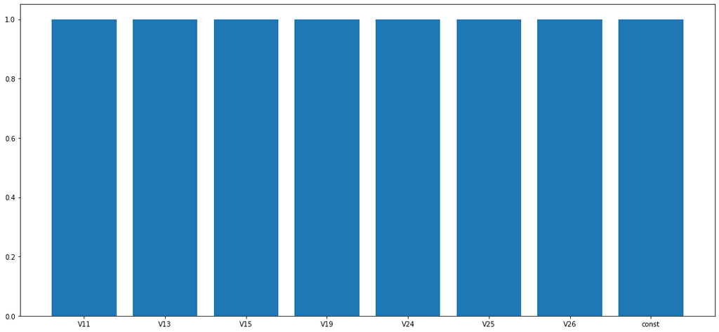

```python
tes = x.assign(const=1)
res = pd.Series([variance_inflation_factor(tes.values, i)
                 for i in range(tes.shape[1])],
                index=tes.columns)

plt.figure(figsize=(15, 7))
plt.bar(res.index, res.values)
plt.tight_layout()
plt.show()
```

### Summary of EDA

1) Data is clean.\ 2) No Null Values.\ 3) Important features are retained and remaining are dropped.\ 4) Most of the features are well distributed around the mean.\ 5) Dataset is highly Imbalanced.

### Handling Imbalanced Data

Since the dataset is highly imbalanced with only 0.17% of fraudulent transactions, direct oversampling or undersampling will be inefficient. A mix of under and oversampling will help us cover more records.

1) Unsampling, non-fraudulent data by selecting random 10% of the tranasactions.\ 2) Oversampling it with fraudulent data to from the balanced dataset.

This can be handled in three ways. 1) Random Over Sampler(ROS)\ 2) Synthetic Data Vault(SDV)\ 3) Synthetic Minority Over-sampling Technique (SMOTE)

### Classifier run pre-prosessing

```python
# Function for Classifier Result
def cl_run(m, te, pr, pr_prob, x):
    print('======================================================')
    print(m)
    print('------------------------------------------------------')
    print('')
    precision = met.precision_score(te, pr)
    recall = met.recall_score(te, pr)
    accuracy = met.accuracy_score(te, pr)
    f1 = met.f1_score(te, pr)
    print('Accuracy of the model is', round(accuracy, 2))
    cl_rep = met.classification_report(te, pr)
    print(cl_rep)
    # Save the results in the DataFrame
    if x == 1:
        Result_sdv.loc[len(Result_sdv.index)] = [m, round(accuracy, 2),
                                             round(precision, 2), round(recall, 2), round(f1, 2)]
    elif x == 2:
        Result_smote.loc[len(Result_smote.index)] = [m, round(accuracy, 2),
                                                   round(precision, 2), round(recall, 2), round(f1, 2)]
    else:
        Result.loc[len(Result.index)] = [m, round(accuracy, 2),
                                         round(precision, 2), round(recall, 2), round(f1, 2)]

    # Plotting Confusion Matrix
    cf_mtx = met.confusion_matrix(te, pr)
    ax = sns.heatmap(cf_mtx, annot=True, cmap='Blues', fmt='g')

    ax.set_title('Confusion Matrix for %s' % m)
    ax.set_xlabel('Predicted Values')
    ax.set_ylabel('Actual Values ')

    ax.xaxis.set_ticklabels(['False', 'True'])
    ax.yaxis.set_ticklabels(['False', 'True'])

    plt.show()

    # Plotting ROC Curve
    plt.title(f'ROC Curve - %s' % m)
    fpr, tpr, thr = met.roc_curve(te, pr_prob)
    plt.plot(fpr,tpr,label="Area under the Curve="+str(round(accuracy, 2)))
    plt.legend(loc=4)
    plt.show()
```

```python
# Storing results in a DataFrame
metrics = ['Model', 'Accuracy Score', ' Precision', 'Recall', 'F1 Score']
Result = pd.DataFrame(columns=metrics)
Result_sdv = pd.DataFrame(columns=metrics)
Result_smote = pd.DataFrame(columns=metrics)
```

## Random Over Sampler

```python
# Mix of Over and Under Sampling.
data_0 = data[data.Class == 0]
data_1 = data[data.Class == 1]

# We'll take random 10% of Non-Fraudulent data
sample_size = round(data_0.shape[0] * 0.1)

data_0_smp = resample(data_0, n_samples=sample_size, random_state=0)
data_smp = pd.concat([data_0_smp, data_1], axis=0)

x_smp = data_smp.drop('Class', axis=1)
y_smp = data_smp.Class

rs = RandomOverSampler(random_state=1)
X, Y = rs.fit_resample(x_smp, y_smp)
print(Y.value_counts())

scl = StandardScaler()
scl.fit(X)
X = scl.transform(X)

x_tr, x_te, y_tr, y_te = train_test_split(X, Y, stratify=Y, random_state=2)
print(y_tr.value_counts())
print(y_te.value_counts())
```

```
0    28325
1    28325
Name: Class, dtype: int64
1    21244
0    21243
Name: Class, dtype: int64
0    7082
1    7081
Name: Class, dtype: int64
```

### Classifier Run - Sampling

```
======================================================
Logistic Regression
------------------------------------------------------

Accuracy of the model is 0.95
              precision    recall  f1-score   support

           0       0.92      0.98      0.95      7082
           1       0.98      0.92      0.95      7081

    accuracy                           0.95     14163
   macro avg       0.95      0.95      0.95     14163
weighted avg       0.95      0.95      0.95     14163
```

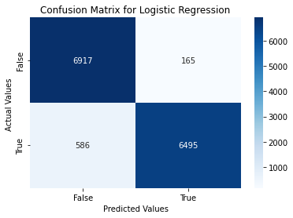

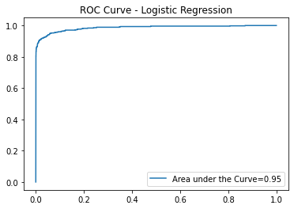

```python
# 1) Logistic Regression
lr_cl = LogisticRegression(max_iter=200, random_state=4)
lr_cl.fit(x_tr, y_tr)
pr_lr = lr_cl.predict(x_te)
pr_prob_lr = lr_cl.predict_proba(x_te)
cl_run('Logistic Regression', y_te, pr_lr, pr_prob_lr[:,-1],0)
```

```
======================================================
Naive Bayes - Gaussian
------------------------------------------------------

Accuracy of the model is 0.92
              precision    recall  f1-score   support

           0       0.88      0.97      0.92      7082
           1       0.97      0.86      0.91      7081

    accuracy                           0.92     14163
   macro avg       0.92      0.92      0.92     14163
weighted avg       0.92      0.92      0.92     14163
```

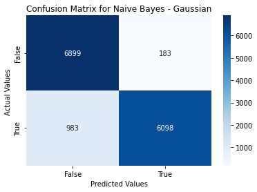

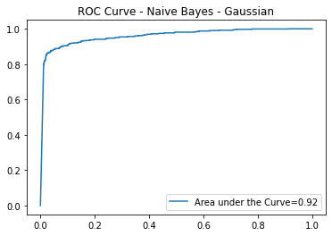

```python
# 2) Naive Bayes - Gaussian
nbg_cl = nb.GaussianNB()
nbg_cl.fit(x_tr, y_tr)
pr_nbg = nbg_cl.predict(x_te)
pr_prob_nbg = nbg_cl.predict_proba(x_te)
cl_run('Naive Bayes - Gaussian', y_te, pr_nbg, pr_prob_nbg[:, -1],0)
```

```
======================================================
Naive Bayes - Bernoulli
------------------------------------------------------

Accuracy of the model is 0.91
              precision    recall  f1-score   support

           0       0.85      0.99      0.91      7082
           1       0.99      0.82      0.90      7081

    accuracy                           0.91     14163
   macro avg       0.92      0.91      0.91     14163
weighted avg       0.92      0.91      0.91     14163
```

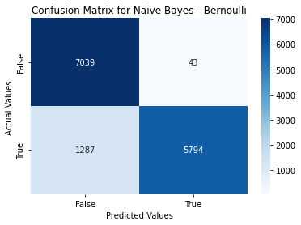

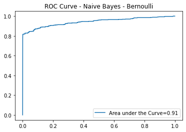

```python
# 3) Naive Bayes - Bernoulli
nbb_cl = nb.BernoulliNB()
nbb_cl.fit(x_tr, y_tr)
pr_nbb = nbb_cl.predict(x_te)
pr_prob_nbb = nbb_cl.predict_proba(x_te)
cl_run('Naive Bayes - Bernoulli', y_te, pr_nbb, pr_prob_nbb[:, -1],0)
```

```
======================================================
Decision Tree - Entropy
------------------------------------------------------

Accuracy of the model is 1.0
              precision    recall  f1-score   support

           0       1.00      1.00      1.00      7082
           1       1.00      1.00      1.00      7081

    accuracy                           1.00     14163
   macro avg       1.00      1.00      1.00     14163
weighted avg       1.00      1.00      1.00     14163
```

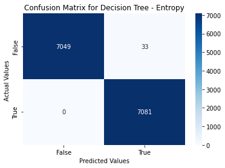

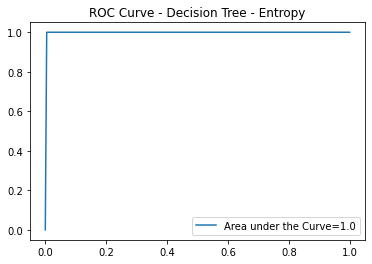

```python
# 4) Decision Tree - Entropy
dt_cl = tree.DecisionTreeClassifier(criterion='entropy', random_state=4)
dt_cl.fit(x_tr, y_tr)
pr_dt = dt_cl.predict(x_te)
pr_prob_dt = dt_cl.predict_proba(x_te)
cl_run('Decision Tree - Entropy', y_te, pr_dt, pr_prob_dt[:, -1],0)
```

```
======================================================
GridSearchCV -> Descision Tree
------------------------------------------------------

Accuracy of the model is 1.0
              precision    recall  f1-score   support

           0       1.00      1.00      1.00      7082
           1       1.00      1.00      1.00      7081

    accuracy                           1.00     14163
   macro avg       1.00      1.00      1.00     14163
weighted avg       1.00      1.00      1.00     14163
```

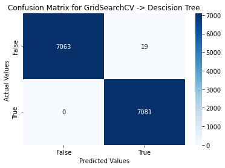

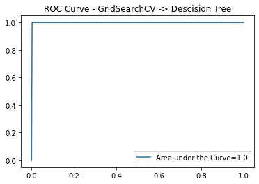

```python
# 5) GridSearchCV over Descision Tree
tree_para = {'criterion':['gini','entropy']}
clf = GridSearchCV(tree.DecisionTreeClassifier(), tree_para)
clf.fit(x_tr, y_tr)
pr_clf = clf.predict(x_te)
pr_prob_clf = clf.predict_proba(x_te)
cl_run('GridSearchCV -> Descision Tree', y_te, pr_clf, pr_prob_clf[:, -1], 0)
```

```
======================================================
Random Forest - Entropy
------------------------------------------------------

Accuracy of the model is 1.0
              precision    recall  f1-score   support

           0       1.00      1.00      1.00      7082
           1       1.00      1.00      1.00      7081

    accuracy                           1.00     14163
   macro avg       1.00      1.00      1.00     14163
weighted avg       1.00      1.00      1.00     14163
```

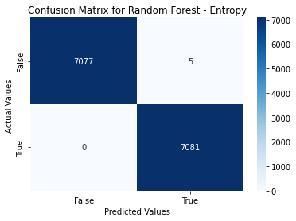

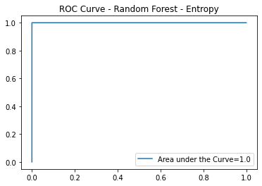

```python
# 6) Random Forest - Entropy
rf_cl = en.RandomForestClassifier(max_features='sqrt', criterion='entropy', random_state=4)
rf_cl.fit(x_tr, y_tr)
pr_rf = rf_cl.predict(x_te)
pr_prob_rf = rf_cl.predict_proba(x_te)
cl_run('Random Forest - Entropy', y_te, pr_rf, pr_prob_rf[:, -1],0)
```

```
======================================================
Random Forest - Gini
------------------------------------------------------

Accuracy of the model is 1.0
              precision    recall  f1-score   support

           0       1.00      1.00      1.00      7082
           1       1.00      1.00      1.00      7081

    accuracy                           1.00     14163
   macro avg       1.00      1.00      1.00     14163
weighted avg       1.00      1.00      1.00     14163
```

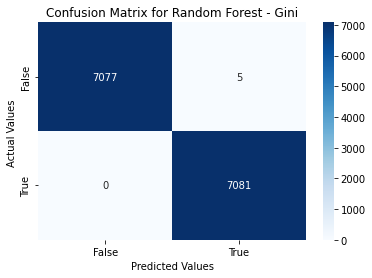

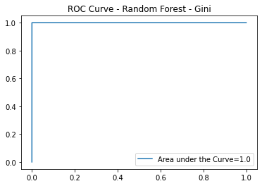

```python
# 7) Random Forest - Gini
rfg_cl = en.RandomForestClassifier(max_features='sqrt', random_state=4)
rfg_cl.fit(x_tr, y_tr)
pr_rfg = rfg_cl.predict(x_te)
pr_prob_rfg = rfg_cl.predict_proba(x_te)
cl_run('Random Forest - Gini', y_te, pr_rfg, pr_prob_rfg[:, -1],0)
```

```
======================================================
GridSearchCV -> Random Forest
------------------------------------------------------

Accuracy of the model is 1.0
              precision    recall  f1-score   support

           0       1.00      1.00      1.00      7082
           1       1.00      1.00      1.00      7081

    accuracy                           1.00     14163
   macro avg       1.00      1.00      1.00     14163
weighted avg       1.00      1.00      1.00     14163
```

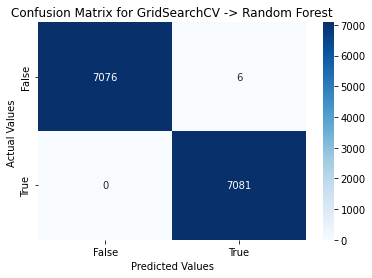

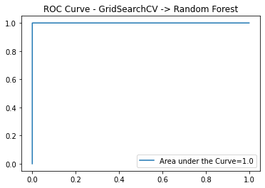

```python
# 8) GridSearchCV over Random Forest
rf_para = {'criterion':['gini','entropy'], 'max_features':['sqrt']}
clf = GridSearchCV(en.RandomForestClassifier(), rf_para)
clf.fit(x_tr, y_tr)
pr_clf = clf.predict(x_te)
pr_prob_clf = clf.predict_proba(x_te)
cl_run('GridSearchCV -> Random Forest', y_te, pr_clf, pr_prob_clf[:, -1], 0)
```

```
======================================================
Gradient Boosting
------------------------------------------------------

Accuracy of the model is 0.99
              precision    recall  f1-score   support

           0       0.99      0.99      0.99      7082
           1       0.99      0.99      0.99      7081

    accuracy                           0.99     14163
   macro avg       0.99      0.99      0.99     14163
weighted avg       0.99      0.99      0.99     14163
```

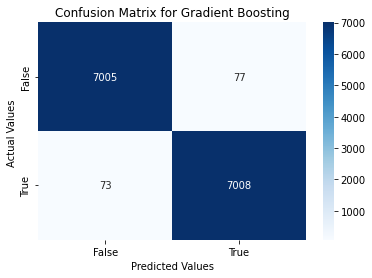

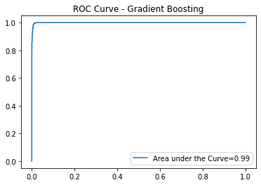

```python
# 9) Gradient Boosting
gb_cl = en.GradientBoostingClassifier()
gb_cl.fit(x_tr, y_tr)
pr_gb = gb_cl.predict(x_te)
pr_prob_gb = gb_cl.predict_proba(x_te)
cl_run('Gradient Boosting', y_te, pr_gb, pr_prob_gb[:, -1],0)
```

```
======================================================
AdaBoost
------------------------------------------------------

Accuracy of the model is 1.0
              precision    recall  f1-score   support

           0       1.00      0.99      1.00      7082
           1       0.99      1.00      1.00      7081

    accuracy                           1.00     14163
   macro avg       1.00      1.00      1.00     14163
weighted avg       1.00      1.00      1.00     14163
```

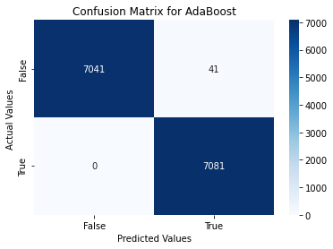

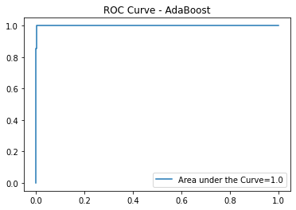

```python
# 10) AdaBoost
ad_cl = en.AdaBoostClassifier(n_estimators=250, random_state=4)
ad_cl.fit(x_tr, y_tr)
pr_ad = ad_cl.predict(x_te)
pr_prob_ad = ad_cl.predict_proba(x_te)
cl_run('AdaBoost', y_te, pr_ad, pr_prob_ad[:, -1],0)
```

```
======================================================
XGBoost
------------------------------------------------------

Accuracy of the model is 1.0
              precision    recall  f1-score   support

           0       1.00      1.00      1.00      7082
           1       1.00      1.00      1.00      7081

    accuracy                           1.00     14163
   macro avg       1.00      1.00      1.00     14163
weighted avg       1.00      1.00      1.00     14163
```

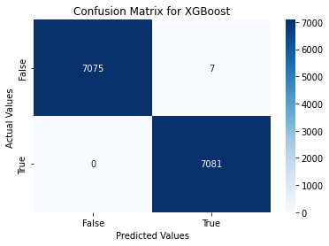

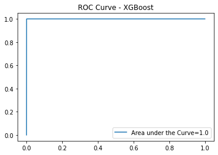

```python
# 11) XGBoost
xgb_cl = XGBClassifier()
xgb_cl.fit(x_tr, y_tr)
pr_xgb = xgb_cl.predict(x_te)
pr_prob_xgb = xgb_cl.predict_proba(x_te)
cl_run('XGBoost', y_te, pr_xgb, pr_prob_xgb[:, -1],0)
```

## Synthetic Data Vault

```python
sdv_model = GaussianCopula()
sdv_model.fit(data_1)
sdv_1 = sdv_model.sample(num_rows=sample_size)
data_sdv = pd.concat([data_0_smp, sdv_1], axis=0)
data_sdv.Class.value_counts()
```

```
0    28325
1    28325
Name: Class, dtype: int64
```

```python
X_sdv = data_sdv.drop('Class', axis=1)
Y_sdv = data_sdv.Class

scl = StandardScaler()
scl.fit(X_sdv)
X_sdv = scl.transform(X_sdv)

x_tr, x_te, y_tr, y_te = train_test_split(X_sdv, Y_sdv, stratify=Y_sdv, random_state=2)
print(y_tr.value_counts())
print(y_te.value_counts())
```

```
1    21244
0    21243
Name: Class, dtype: int64
0    7082
1    7081
Name: Class, dtype: int64
```

### Classifier Run - Synthetic Data Vault (SDV)

```
======================================================
Logistic Regression
------------------------------------------------------

Accuracy of the model is 0.96
              precision    recall  f1-score   support

           0       0.94      0.98      0.96      7082
           1       0.98      0.94      0.96      7081

    accuracy                           0.96     14163
   macro avg       0.96      0.96      0.96     14163
weighted avg       0.96      0.96      0.96     14163
```

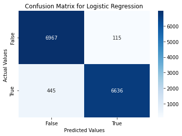

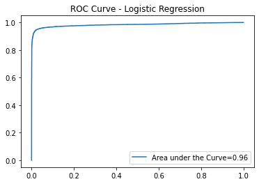

```python
# 1) Logistic Regression
lr_cl = LogisticRegression(max_iter=200, random_state=4)
lr_cl.fit(x_tr, y_tr)
pr_lr = lr_cl.predict(x_te)
pr_prob_lr = lr_cl.predict_proba(x_te)
cl_run('Logistic Regression', y_te, pr_lr, pr_prob_lr[:,-1], 1)
```

```
======================================================
Naive Bayes - Gaussian
------------------------------------------------------

Accuracy of the model is 0.96
              precision    recall  f1-score   support

           0       0.95      0.97      0.96      7082
           1       0.97      0.95      0.96      7081

    accuracy                           0.96     14163
   macro avg       0.96      0.96      0.96     14163
weighted avg       0.96      0.96      0.96     14163
```

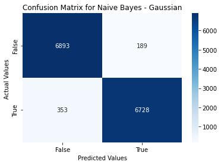

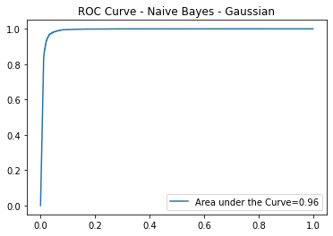

```python
# 2) Naive Bayes - Gaussian
nbg_cl = nb.GaussianNB()
nbg_cl.fit(x_tr, y_tr)
pr_nbg = nbg_cl.predict(x_te)
pr_prob_nbg = nbg_cl.predict_proba(x_te)
cl_run('Naive Bayes - Gaussian', y_te, pr_nbg, pr_prob_nbg[:, -1], 1)
```

```
======================================================
Naive Bayes - Bernoulli
------------------------------------------------------

Accuracy of the model is 0.93
              precision    recall  f1-score   support

           0       0.87      1.00      0.93      7082
           1       1.00      0.85      0.92      7081

    accuracy                           0.93     14163
   macro avg       0.93      0.93      0.92     14163
weighted avg       0.93      0.93      0.92     14163
```

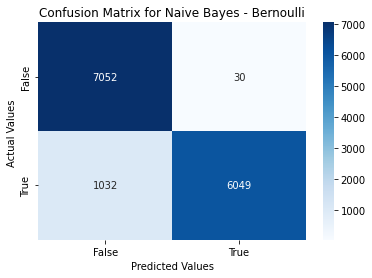

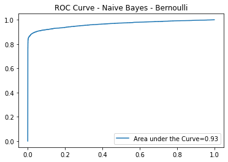

```python
# 3) Naive Bayes - Bernoulli
nbb_cl = nb.BernoulliNB()
nbb_cl.fit(x_tr, y_tr)
pr_nbb = nbb_cl.predict(x_te)
pr_prob_nbb = nbb_cl.predict_proba(x_te)
cl_run('Naive Bayes - Bernoulli', y_te, pr_nbb, pr_prob_nbb[:, -1], 1)
```

```
======================================================
Decision Tree - Entropy
------------------------------------------------------

Accuracy of the model is 0.99
              precision    recall  f1-score   support

           0       0.99      0.99      0.99      7082
           1       0.99      0.99      0.99      7081

    accuracy                           0.99     14163
   macro avg       0.99      0.99      0.99     14163
weighted avg       0.99      0.99      0.99     14163
```

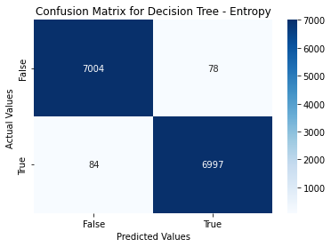

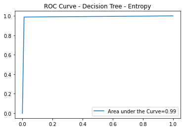

```python
# 4) Decision Tree - Entropy
dt_cl = tree.DecisionTreeClassifier(criterion='entropy', random_state=4)
dt_cl.fit(x_tr, y_tr)
pr_dt = dt_cl.predict(x_te)
pr_prob_dt = dt_cl.predict_proba(x_te)
cl_run('Decision Tree - Entropy', y_te, pr_dt, pr_prob_dt[:, -1], 1)
```

```
======================================================
GridSearchCV -> Descision Tree
------------------------------------------------------

Accuracy of the model is 0.99
              precision    recall  f1-score   support

           0       0.99      0.99      0.99      7082
           1       0.99      0.99      0.99      7081

    accuracy                           0.99     14163
   macro avg       0.99      0.99      0.99     14163
weighted avg       0.99      0.99      0.99     14163
```

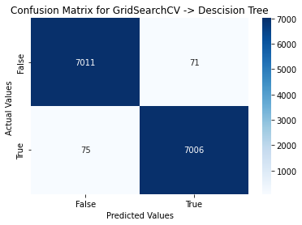

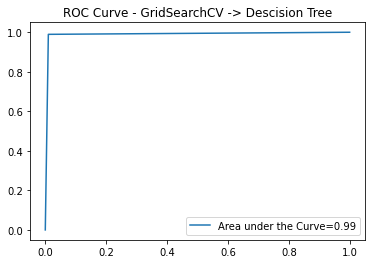

```python
# 5) GridSearchCV over Descision Tree
tree_para = {'criterion':['gini','entropy']}
clf = GridSearchCV(tree.DecisionTreeClassifier(), tree_para)
clf.fit(x_tr, y_tr)
pr_clf = clf.predict(x_te)
pr_prob_clf = clf.predict_proba(x_te)
cl_run('GridSearchCV -> Descision Tree', y_te, pr_clf, pr_prob_clf[:, -1], 1)
```

```
======================================================
Random Forest - Entropy
------------------------------------------------------

Accuracy of the model is 1.0
              precision    recall  f1-score   support

           0       0.99      1.00      1.00      7082
           1       1.00      0.99      1.00      7081

    accuracy                           1.00     14163
   macro avg       1.00      1.00      1.00     14163
weighted avg       1.00      1.00      1.00     14163
```

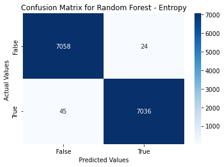

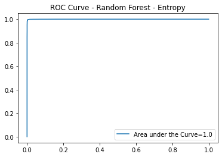

```python
# 6) Random Forest - Entropy
rf_cl = en.RandomForestClassifier(max_features='sqrt', criterion='entropy', random_state=4)
rf_cl.fit(x_tr, y_tr)
pr_rf = rf_cl.predict(x_te)
pr_prob_rf = rf_cl.predict_proba(x_te)
cl_run('Random Forest - Entropy', y_te, pr_rf, pr_prob_rf[:, -1], 1)
```

```
======================================================
Random Forest - Gini
------------------------------------------------------

Accuracy of the model is 1.0
              precision    recall  f1-score   support

           0       0.99      1.00      1.00      7082
           1       1.00      0.99      1.00      7081

    accuracy                           1.00     14163
   macro avg       1.00      1.00      1.00     14163
weighted avg       1.00      1.00      1.00     14163
```

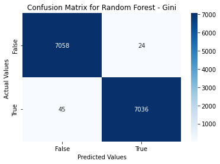

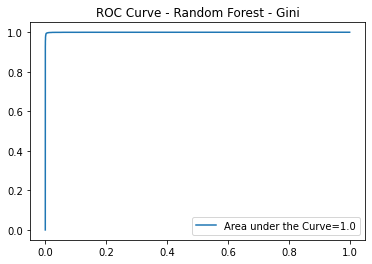

```python
# 7) Random Forest - Gini
rfg_cl = en.RandomForestClassifier(max_features='sqrt', random_state=4)
rfg_cl.fit(x_tr, y_tr)
pr_rfg = rfg_cl.predict(x_te)
pr_prob_rfg = rfg_cl.predict_proba(x_te)
cl_run('Random Forest - Gini', y_te, pr_rfg, pr_prob_rfg[:, -1], 1)
```

```
======================================================
GridSearchCV -> Random Forest
------------------------------------------------------

Accuracy of the model is 1.0
              precision    recall  f1-score   support

           0       0.99      1.00      1.00      7082
           1       1.00      0.99      1.00      7081

    accuracy                           1.00     14163
   macro avg       1.00      1.00      1.00     14163
weighted avg       1.00      1.00      1.00     14163
```

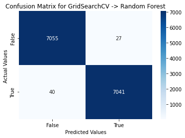

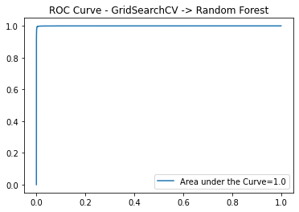

```python
# 8) GridSearchCV over Random Forest
rf_para = {'criterion':['gini','entropy'], 'max_features':['sqrt']}
clf = GridSearchCV(en.RandomForestClassifier(), rf_para)
clf.fit(x_tr, y_tr)
pr_clf = clf.predict(x_te)
pr_prob_clf = clf.predict_proba(x_te)
cl_run('GridSearchCV -> Random Forest', y_te, pr_clf, pr_prob_clf[:, -1], 1)
```

```
======================================================
Gradient Boosting
------------------------------------------------------

Accuracy of the model is 0.99
              precision    recall  f1-score   support

           0       0.99      0.99      0.99      7082
           1       0.99      0.99      0.99      7081

    accuracy                           0.99     14163
   macro avg       0.99      0.99      0.99     14163
weighted avg       0.99      0.99      0.99     14163
```

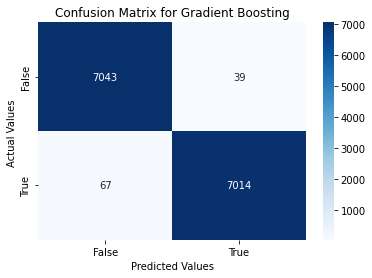

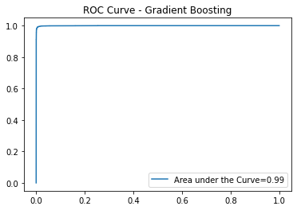

```python
# 9) Gradient Boosting
gb_cl = en.GradientBoostingClassifier()
gb_cl.fit(x_tr, y_tr)
pr_gb = gb_cl.predict(x_te)
pr_prob_gb = gb_cl.predict_proba(x_te)
cl_run('Gradient Boosting', y_te, pr_gb, pr_prob_gb[:, -1], 1)
```

```
======================================================
AdaBoost
------------------------------------------------------

Accuracy of the model is 0.99
              precision    recall  f1-score   support

           0       0.99      0.99      0.99      7082
           1       0.99      0.99      0.99      7081

    accuracy                           0.99     14163
   macro avg       0.99      0.99      0.99     14163
weighted avg       0.99      0.99      0.99     14163
```

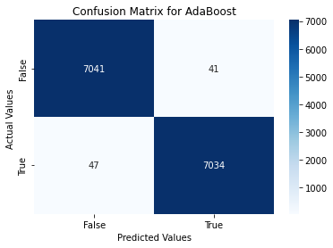

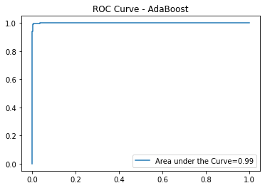

```python
# 10) AdaBoost
ad_cl = en.AdaBoostClassifier(n_estimators=250, random_state=4)
ad_cl.fit(x_tr, y_tr)
pr_ad = ad_cl.predict(x_te)
pr_prob_ad = ad_cl.predict_proba(x_te)
cl_run('AdaBoost', y_te, pr_ad, pr_prob_ad[:, -1], 1)
```

```
======================================================
XGBoost
------------------------------------------------------

Accuracy of the model is 1.0
              precision    recall  f1-score   support

           0       1.00      1.00      1.00      7082
           1       1.00      1.00      1.00      7081

    accuracy                           1.00     14163
   macro avg       1.00      1.00      1.00     14163
weighted avg       1.00      1.00      1.00     14163
```

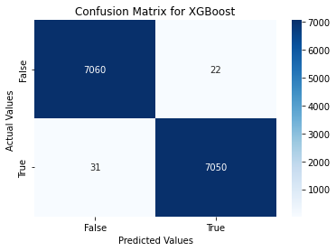

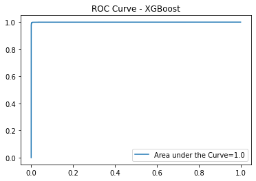

```python
# 11) XGBoost
xgb_cl = XGBClassifier()
xgb_cl.fit(x_tr, y_tr)
pr_xgb = xgb_cl.predict(x_te)
pr_prob_xgb = xgb_cl.predict_proba(x_te)
cl_run('XGBoost', y_te, pr_xgb, pr_prob_xgb[:, -1], 1)
```